# Qualifying Standards for World Masters Championships -Predictions

16 September 2018

# 1 Age and Bodyweight distribution

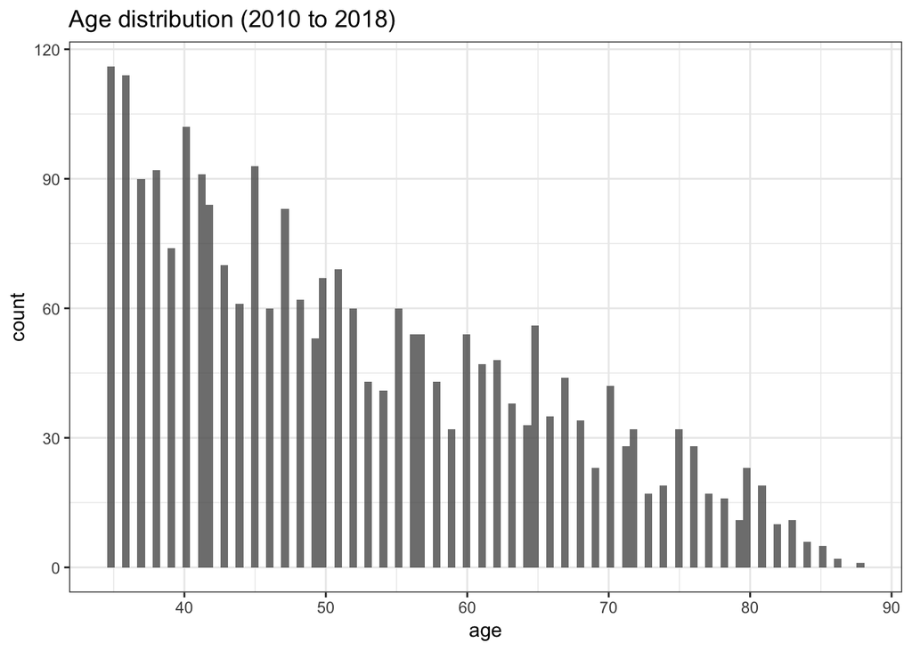

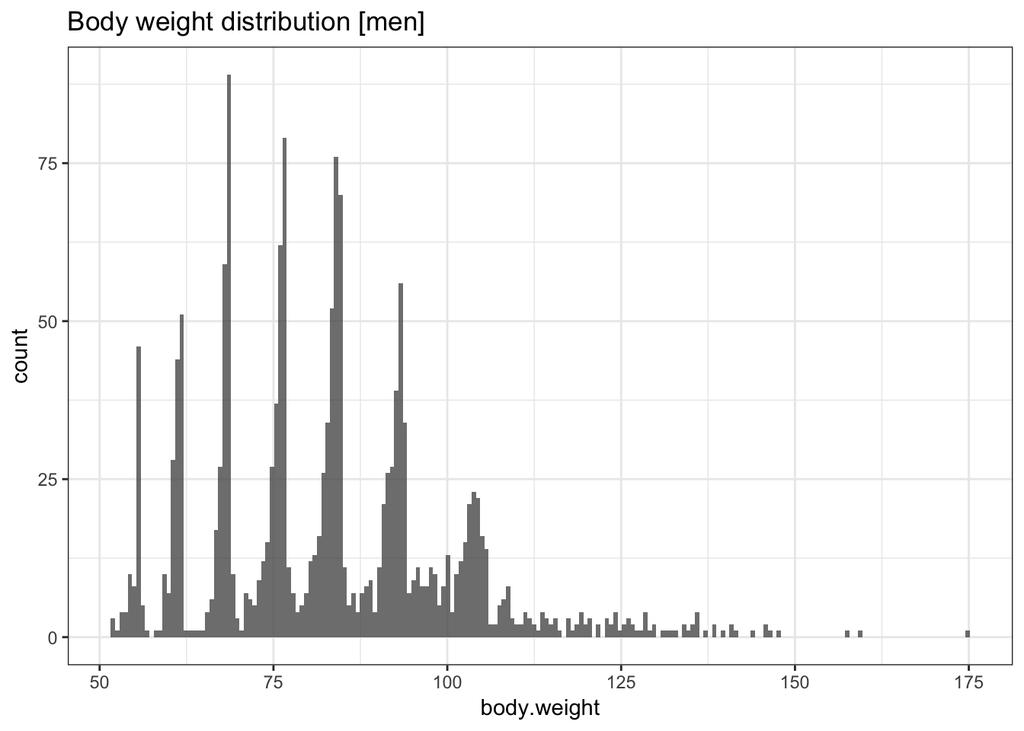

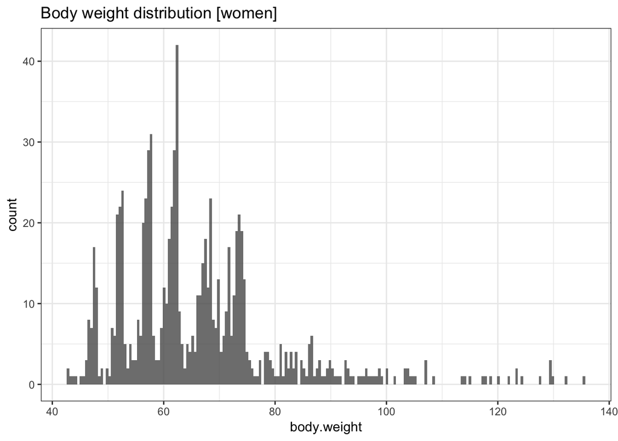

Due the body weight and age distributions it is reasonable to calculate qualifying totals [in kg] based on SMF cutoff values calculated for the top body weight in each weight class and the youngest age in each age class. A decision needs to be made for the heaviest weight classes. In this document the reference weight was 120 kg for men and 100kg for women.

# 2 SMF distribution

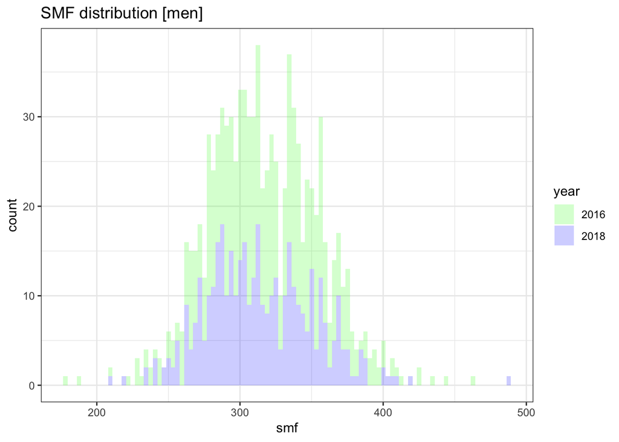

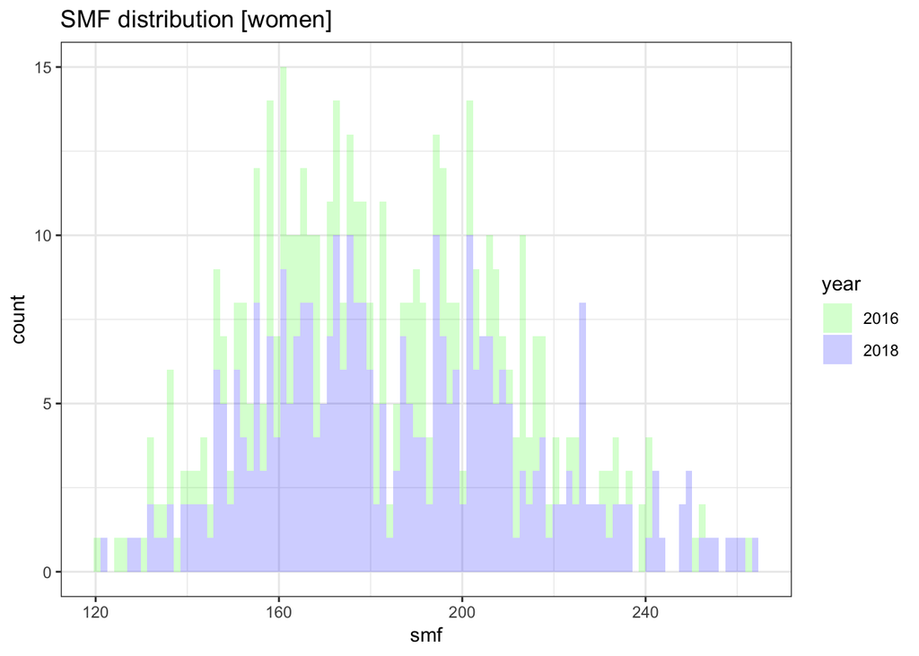

It looks like there is a bimodal distribution for men (200-330 and 330-450) and for women (120-180 and 180-250).

# 3 SMF trend over time

## 3.1 SMF trend over time by age category and gender

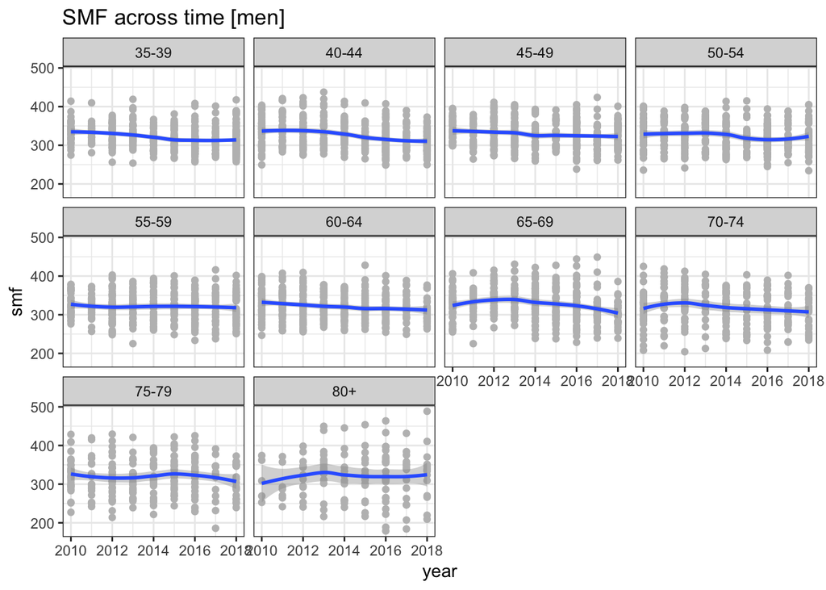

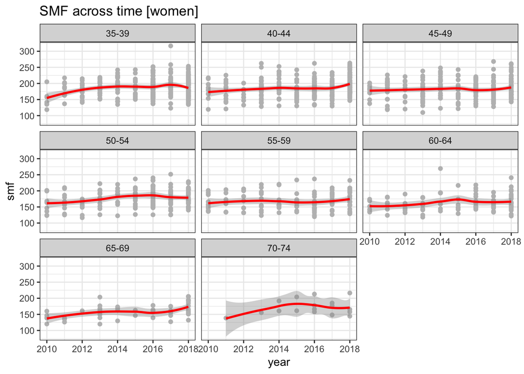

For some age categories for men there is slight downward trend from 2010 to 2018 in the SMF. For women it is an upward trend.

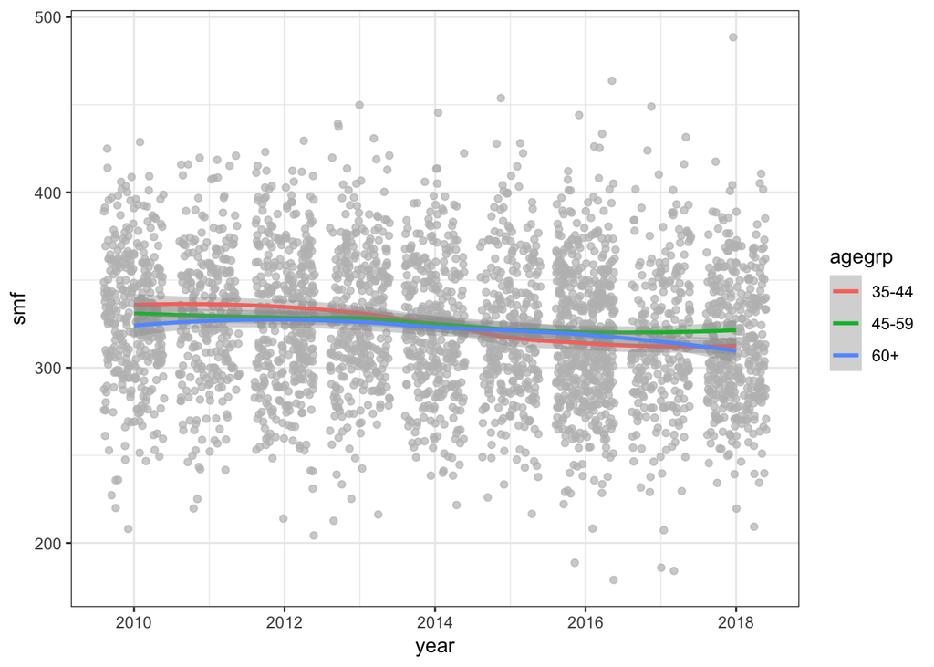

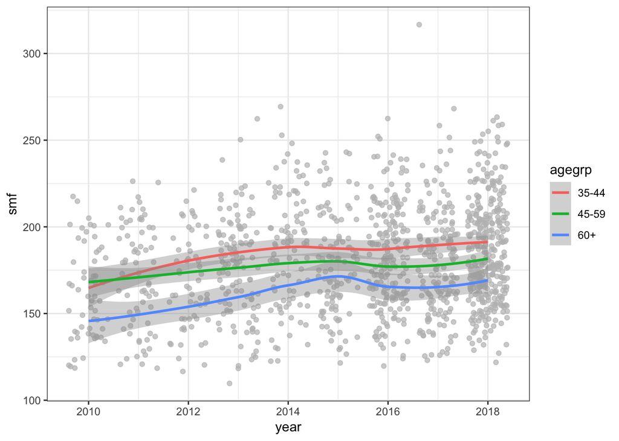

Comment: the separation of the lines for women does indicate that the SMF formula may not fit well for to women’s data. Here there are more women since 2016, and the distance between the curves is similar 2016 to 2018.

## 3.2 Distributions of SMF in 2018 (with quantile 0.2)

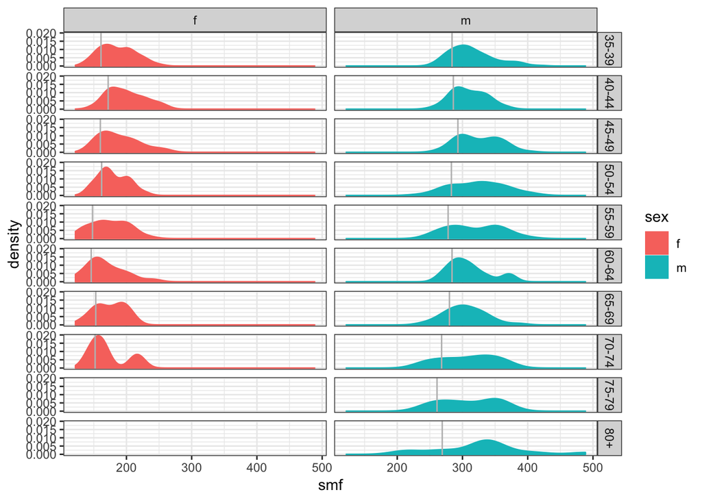

The distributions of SMF differ across the age classes. In some age groups there is a bimodal distribution. The oldest age groups are shifted to the left (lower end). This can also be seen by looking at the line for the 0.2 quantile of each distribution.

## 3.3 Quantile regression lines for SMF across time

Quantile regression lines (10, 20,30, 40, 50, 75 %) for men

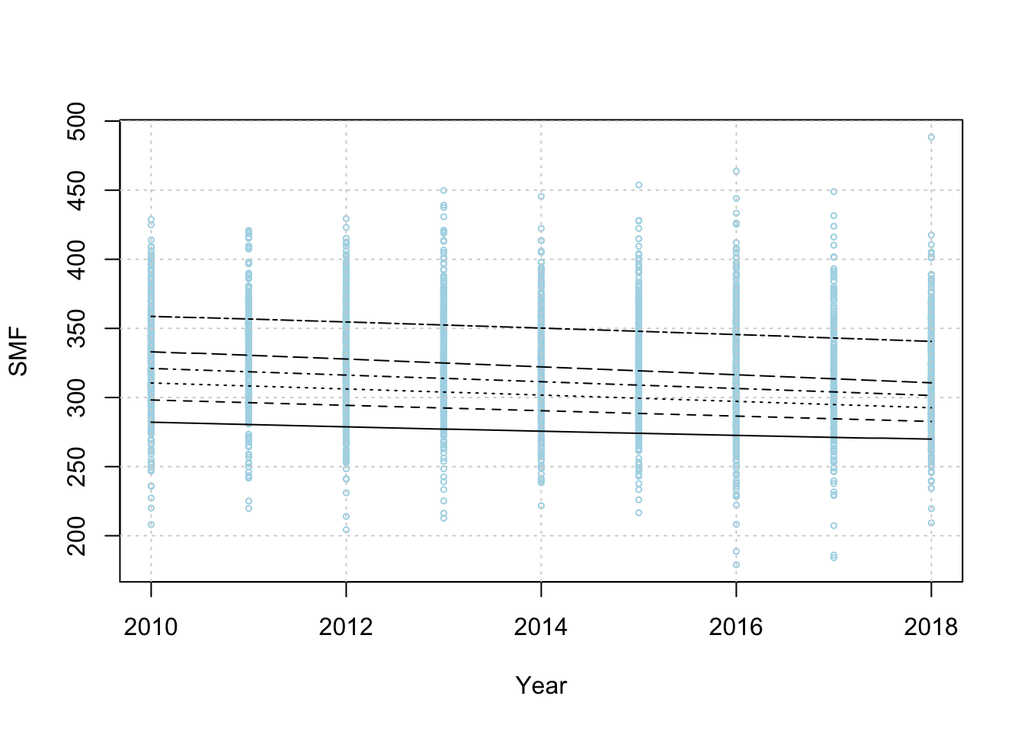

Quantile regression lines (10, 20,30, 40, 50, 75 %) for women

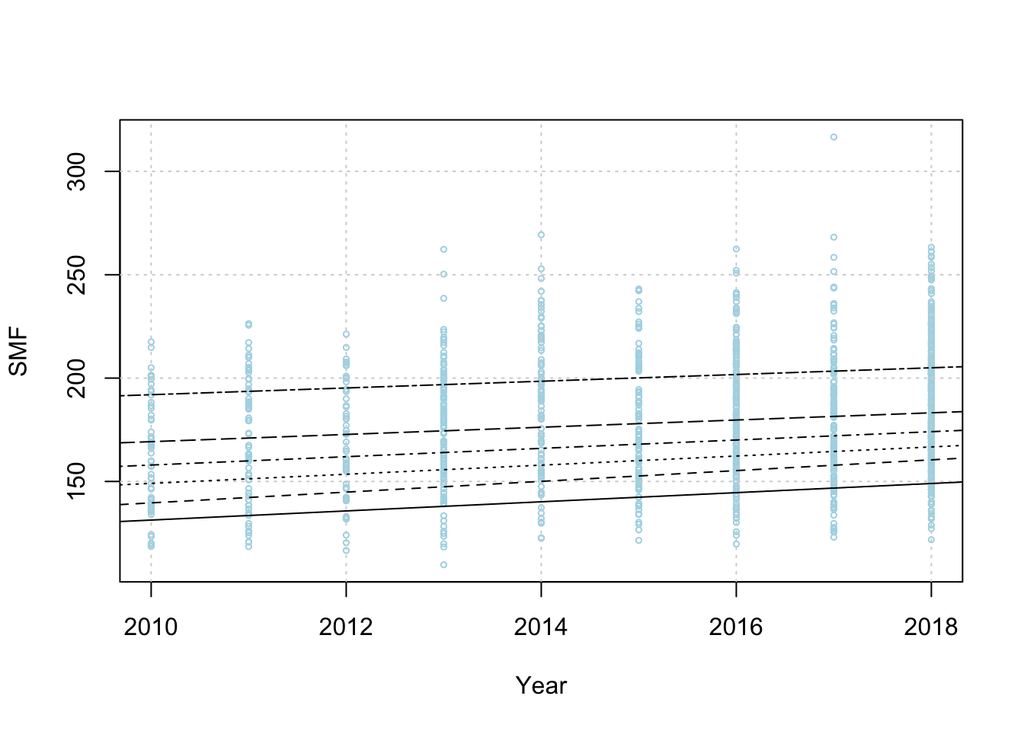

## 3.4 Tables of participants, adjusting bodyweight for new weight categories

This indicates that the most pressure is in the younger age groups in the middle weight categories.

IWF 2016 in Heinsheim, Germany

| W35 | W40 | W45 | W50 | W55 | W60 | W65 | W70 | W75 | W80 | weightcat |
| --- | --- | --- | --- | --- | --- | --- | --- | --- | --- | --- |
| 1 | 0 | 0 | 0 | 0 | 0 | 0 | 0 | 0 | 0 | 45 |
| 6 | 3 | 1 | 1 | 1 | 1 | 0 | 0 | 0 | 0 | 49 |
| 5 | 7 | 2 | 3 | 3 | 4 | 1 | 2 | 2 | 0 | 55 |
| 11 | 7 | 6 | 6 | 2 | 2 | 1 | 1 | 1 | 0 | 59 |
| 11 | 7 | 7 | 3 | 3 | 2 | 1 | 1 | 1 | 0 | 64 |
| 11 | 6 | 3 | 7 | 2 | 2 | 1 | 0 | 0 | 0 | 71 |
| 10 | 5 | 8 | 3 | 2 | 2 | 0 | 0 | 0 | 0 | 76 |
| 1 | 1 | 1 | 0 | 2 | 1 | 1 | 0 | 0 | 0 | 81 |
| 1 | 1 | 0 | 0 | 2 | 0 | 0 | 0 | 0 | 0 | 87 |
| 2 | 4 | 5 | 3 | 1 | 0 | 0 | 0 | 0 | 0 | 87+ |

| M35 | M40 | M45 | M50 | M55 | M60 | M65 | M70 | M75 | M80 | weightcat |
| --- | --- | --- | --- | --- | --- | --- | --- | --- | --- | --- |
| 0 | 1 | 2 | 0 | 1 | 2 | 1 | 0 | 0 | 0 | 55 |
| 4 | 5 | 1 | 2 | 6 | 2 | 6 | 1 | 1 | 3 | 61 |
| 4 | 3 | 3 | 3 | 6 | 8 | 6 | 4 | 4 | 4 | 67 |
| 5 | 7 | 7 | 11 | 8 | 5 | 12 | 9 | 9 | 5 | 73 |
| 9 | 16 | 12 | 11 | 11 | 10 | 10 | 7 | 7 | 8 | 81 |
| 22 | 23 | 19 | 13 | 10 | 13 | 11 | 8 | 8 | 2 | 89 |
| 15 | 15 | 17 | 9 | 7 | 10 | 9 | 7 | 7 | 6 | 96 |
| 1 | 2 | 5 | 5 | 8 | 3 | 3 | 2 | 2 | 0 | 102 |
| 8 | 4 | 10 | 8 | 5 | 5 | 2 | 3 | 3 | 1 | 109 |
| 6 | 10 | 2 | 7 | 5 | 3 | 2 | 1 | 1 | 0 | 109+ |

IWF 2016, Median SMF in each subgroup

|  | 35-39 | 40-44 | 45-49 | 50-54 | 55-59 | 60-64 | 65-69 | 70-74 | 75-79 |
| --- | --- | --- | --- | --- | --- | --- | --- | --- | --- |
| 45 | 198.5 | NA | NA | NA | NA | NA | NA | NA | NA |
| 49 | 217.3 | 207.2 | 191.3 | 233.2 | 147.1 | 200.9 | NA | NA | NA |
| 55 | 171.6 | 177.1 | 213.2 | 214.8 | 196.8 | 162.8 | 177.7 | 185.4 | 0 |
| 59 | 201.3 | 189.8 | 181.2 | 188.0 | 163.6 | 175.2 | 156.5 | 166.1 | NA |
| 64 | 181.5 | 206.2 | 186.3 | 172.4 | 189.0 | 104.2 | 164.1 | 177.4 | NA |
| 71 | 171.5 | 168.6 | 184.1 | 167.2 | 128.3 | 171.3 | 139.4 | NA | NA |
| 76 | 168.4 | 161.3 | 184.6 | 188.2 | 164.8 | 75.2 | NA | NA | NA |
| 81 | 155.5 | 132.4 | 143.9 | NA | 153.1 | 142.6 | 161.4 | NA | NA |
| 87 | 152.8 | 206.8 | NA | NA | 62.0 | NA | NA | NA | NA |
| 87+ | 147.8 | 170.1 | 177.0 | 193.4 | 132.1 | NA | NA | NA | NA |

|  | 35-39 | 40-44 | 45-49 | 50-54 | 55-59 | 60-64 | 65-69 | 70-74 | 75-79 | 80+ |
| --- | --- | --- | --- | --- | --- | --- | --- | --- | --- | --- |
| 55 | NA | 305.5 | 264.9 | NA | 336.9 | 295.0 | 313.5 | NA | NA | NA |
| 61 | 289.4 | 283.5 | 313.8 | 271.2 | 294.2 | 282.1 | 350.5 | 364.7 | 292.7 | 357.0 |
| 67 | 296.6 | 316.8 | 340.7 | 309.9 | 318.7 | 305.3 | 349.8 | 281.5 | 332.3 | 335.7 |
| 73 | 309.6 | 279.7 | 342.3 | 288.8 | 326.2 | 341.9 | 312.1 | 277.3 | 370.2 | 316.2 |
| 81 | 322.9 | 315.1 | 313.5 | 291.9 | 332.4 | 315.4 | 322.3 | 320.9 | 318.1 | 345.6 |
| 89 | 295.9 | 305.1 | 300.4 | 303.5 | 353.2 | 323.4 | 321.7 | 306.9 | 294.7 | 132.1 |
| 96 | 293.3 | 311.6 | 323.1 | 306.9 | 341.4 | 296.8 | 299.5 | 316.7 | 334.2 | 280.4 |
| 102 | 367.9 | 288.7 | 342.0 | 302.1 | 281.7 | 314.1 | 303.4 | 304.6 | NA | NA |
| 109 | 304.5 | 338.2 | 343.7 | 333.2 | 323.6 | 254.7 | 309.2 | 300.9 | 317.2 | 0.0 |
| 109+ | 327.4 | 303.3 | 299.0 | 312.2 | 322.6 | 307.5 | 354.4 | 347.5 | 323.5 | NA |

IWF 2018 in Barcelona

| W35 | W40 | W45 | W50 | W55 | W60 | W65 | W70 | W75 | W80 | weightcat |
| --- | --- | --- | --- | --- | --- | --- | --- | --- | --- | --- |
| 0 | 1 | 0 | 0 | 0 | 1 | 0 | 0 | 0 | 0 | 45 |
| 4 | 8 | 2 | 3 | 2 | 1 | 1 | 0 | 0 | 0 | 49 |
| 8 | 8 | 7 | 5 | 2 | 3 | 3 | 1 | 1 | 0 | 55 |
| 23 | 10 | 7 | 3 | 3 | 4 | 5 | 1 | 1 | 0 | 59 |
| 25 | 19 | 7 | 12 | 4 | 4 | 2 | 0 | 0 | 0 | 64 |
| 27 | 14 | 14 | 6 | 3 | 1 | 1 | 1 | 1 | 0 | 71 |
| 15 | 14 | 6 | 5 | 4 | 4 | 1 | 1 | 1 | 0 | 76 |
| 1 | 2 | 3 | 2 | 0 | 0 | 0 | 0 | 0 | 0 | 81 |
| 6 | 3 | 3 | 3 | 3 | 1 | 0 | 0 | 0 | 0 | 87 |
| 11 | 4 | 2 | 1 | 2 | 2 | 0 | 0 | 0 | 0 | 87+ |

| M35 | M40 | M45 | M50 | M55 | M60 | M65 | M70 | M75 | M80 | weightcat |
| --- | --- | --- | --- | --- | --- | --- | --- | --- | --- | --- |
| 0 | 2 | 0 | 1 | 0 | 1 | 1 | 2 | 2 | 0 | 55 |
| 3 | 5 | 6 | 3 | 3 | 1 | 3 | 2 | 2 | 2 | 61 |
| 2 | 2 | 1 | 2 | 4 | 4 | 4 | 4 | 4 | 0 | 67 |
| 16 | 15 | 2 | 3 | 7 | 7 | 4 | 4 | 4 | 6 | 73 |
| 15 | 10 | 10 | 5 | 8 | 5 | 4 | 6 | 6 | 1 | 81 |
| 28 | 11 | 12 | 11 | 6 | 3 | 5 | 5 | 5 | 3 | 89 |
| 14 | 14 | 7 | 5 | 3 | 3 | 3 | 4 | 4 | 0 | 96 |
| 4 | 2 | 5 | 1 | 1 | 1 | 5 | 0 | 0 | 2 | 102 |
| 6 | 7 | 6 | 4 | 4 | 4 | 2 | 2 | 2 | 1 | 109 |
| 5 | 4 | 0 | 7 | 2 | 2 | 1 | 0 | 0 | 0 | 109+ |

IWF 2018, Median SMF in each subgroup

|  | 35-39 | 40-44 | 45-49 | 50-54 | 55-59 | 60-64 | 65-69 | 70-74 |
| --- | --- | --- | --- | --- | --- | --- | --- | --- |
| 45 | NA | 201.8 | NA | NA | NA | 199.4 | NA | NA |
| 49 | 194.5 | 216.2 | 179.6 | 171.9 | 202.1 | 152.2 | 191.7 | NA |
| 55 | 181.6 | 206.8 | 171.9 | 187.4 | 166.9 | 189.0 | 176.2 | 216.4 |
| 59 | 189.0 | 207.6 | 205.4 | 204.1 | 183.2 | 174.1 | 185.1 | 157.7 |
| 64 | 179.4 | 198.8 | 194.9 | 171.5 | 165.5 | 157.4 | 155.6 | NA |
| 71 | 179.1 | 195.3 | 184.6 | 183.8 | 203.0 | 178.2 | 195.2 | 144.3 |
| 76 | 178.1 | 172.6 | 166.4 | 150.9 | 165.1 | 150.4 | 156.2 | 165.3 |
| 81 | 149.8 | 213.4 | 158.4 | 171.3 | NA | NA | NA | NA |
| 87 | 184.6 | 201.0 | 164.5 | 169.5 | 143.1 | 127.1 | NA | NA |
| 87+ | 177.0 | 170.5 | 86.8 | 205.6 | 163.2 | 140.7 | NA | NA |

|  | 35-39 | 40-44 | 45-49 | 50-54 | 55-59 | 60-64 | 65-69 | 70-74 | 75-79 | 80+ |
| --- | --- | --- | --- | --- | --- | --- | --- | --- | --- | --- |
| 55 | NA | 271.1 | NA | 234.3 | NA | 311.3 | 324.3 | 317.0 | NA | NA |
| 61 | 284.3 | 296.9 | 301.8 | 283.4 | 310.6 | 269.9 | 295.4 | 307.3 | 352.3 | 367.1 |
| 67 | 303.4 | 297.8 | 311.2 | 341.1 | 344.0 | 292.1 | 329.1 | 307.5 | 261.1 | NA |
| 73 | 303.8 | 281.4 | 274.8 | 323.0 | 300.6 | 316.8 | 303.4 | 267.1 | 350.8 | 341.9 |
| 81 | 305.7 | 317.4 | 299.9 | 325.6 | 304.4 | 293.1 | 308.6 | 277.7 | 349.3 | 351.2 |
| 89 | 297.5 | 324.4 | 327.7 | 324.3 | 332.8 | 298.1 | 310.3 | 338.2 | 269.8 | 333.8 |
| 96 | 316.2 | 309.4 | 308.6 | 357.1 | 349.9 | 313.2 | 301.2 | 328.4 | 348.8 | NA |
| 102 | 288.8 | 300.2 | 360.0 | 335.3 | 282.2 | 291.7 | 283.4 | NA | 292.1 | 243.0 |
| 109 | 312.5 | 316.3 | 325.0 | 316.2 | 296.0 | 327.6 | 292.1 | 360.6 | 250.7 | 309.4 |
| 109+ | 336.0 | 318.9 | NA | 305.1 | 281.4 | 290.0 | 256.8 | NA | 289.5 | NA |

IWF 2018, first quartile SMF in each subgroup

|  | 35-39 | 40-44 | 45-49 | 50-54 | 55-59 | 60-64 | 65-69 | 70-74 |
| --- | --- | --- | --- | --- | --- | --- | --- | --- |
| 45 | NA | 201.8 | NA | NA | NA | 199.4 | NA | NA |
| 49 | 156.9 | 190.1 | 172.5 | 171.4 | 198.7 | 152.2 | 191.7 | NA |
| 55 | 172.3 | 181.9 | 156.5 | 169.2 | 166.8 | 164.1 | 170.7 | 216.4 |
| 59 | 162.5 | 187.1 | 184.5 | 186.5 | 169.8 | 163.7 | 151.2 | 157.7 |
| 64 | 160.4 | 171.7 | 173.5 | 156.7 | 149.4 | 151.0 | 153.3 | NA |
| 71 | 161.2 | 175.0 | 169.6 | 174.3 | 165.9 | 178.2 | 195.2 | 144.3 |
| 76 | 160.2 | 158.0 | 157.4 | 150.5 | 162.3 | 145.2 | 156.2 | 165.3 |
| 81 | 149.8 | 206.9 | 79.2 | 171.0 | NA | NA | NA | NA |
| 87 | 163.3 | 182.2 | 160.5 | 165.3 | 139.6 | 127.1 | NA | NA |
| 87+ | 155.9 | 167.2 | 43.4 | 205.6 | 147.6 | 131.3 | NA | NA |

[output not shown]

# 4 SMF cutoffs qualifying total and number of participants

Qualifying standards and number of 2018 women qualifying

| agecat | wtcat | age | mf | weight | smf | sinclair | tot | qualsmf | qual.lift | num.lift | qual.pct |
| --- | --- | --- | --- | --- | --- | --- | --- | --- | --- | --- | --- |
| 35-39 | 49 | 35 | 1.072 | 49 | 165 | 153.9 | 99 | 1 | 2 | 4 | 50 |
| 35-39 | 55 | 35 | 1.072 | 55 | 165 | 153.9 | 107 | 1 | 7 | 8 | 87.5 |
| 35-39 | 59 | 35 | 1.072 | 59 | 165 | 153.9 | 113 | 1 | 16 | 23 | 69.6 |
| 35-39 | 64 | 35 | 1.072 | 64 | 165 | 153.9 | 119 | 1 | 17 | 25 | 68 |
| 35-39 | 71 | 35 | 1.072 | 71 | 165 | 153.9 | 126 | 1 | 18 | 27 | 66.7 |
| 35-39 | 76 | 35 | 1.072 | 76 | 165 | 153.9 | 130 | 1 | 11 | 15 | 73.3 |
| 35-39 | 87 | 35 | 1.072 | 87 | 165 | 153.9 | 138 | 1 | 4 | 6 | 66.7 |
| 35-39 | 87+ | 35 | 1.072 | 100 | 165 | 153.9 | 145 | 1 | 6 | 11 | 54.5 |
| 40-44 | 45 | 40 | 1.135 | 45 | 160 | 141 | 84 | 1 | 1 | 1 | 100 |
| 40-44 | 49 | 40 | 1.135 | 49 | 160 | 141 | 90 | 1 | 8 | 8 | 100 |
| 40-44 | 55 | 40 | 1.135 | 55 | 160 | 141 | 98 | 1 | 8 | 8 | 100 |
| 40-44 | 59 | 40 | 1.135 | 59 | 160 | 141 | 103 | 1 | 10 | 10 | 100 |
| 40-44 | 64 | 40 | 1.135 | 64 | 160 | 141 | 109 | 1 | 17 | 19 | 89.5 |
| 40-44 | 71 | 40 | 1.135 | 71 | 160 | 141 | 115 | 1 | 12 | 14 | 85.7 |
| 40-44 | 76 | 40 | 1.135 | 76 | 160 | 141 | 119 | 1 | 10 | 14 | 71.4 |
| 40-44 | 81 | 40 | 1.135 | 81 | 160 | 141 | 123 | 1 | 2 | 2 | 100 |
| 40-44 | 87 | 40 | 1.135 | 87 | 160 | 141 | 126 | 1 | 3 | 3 | 100 |
| 40-44 | 87+ | 40 | 1.135 | 100 | 160 | 141 | 132 | 1 | 3 | 4 | 75 |
| 45-49 | 49 | 45 | 1.203 | 49 | 155 | 128.8 | 83 | 1 | 2 | 2 | 100 |
| 45-49 | 55 | 45 | 1.203 | 55 | 155 | 128.8 | 90 | 1 | 6 | 7 | 85.7 |
| 45-49 | 59 | 45 | 1.203 | 59 | 155 | 128.8 | 94 | 1 | 6 | 7 | 85.7 |
| 45-49 | 64 | 45 | 1.203 | 64 | 155 | 128.8 | 99 | 1 | 6 | 7 | 85.7 |
| 45-49 | 71 | 45 | 1.203 | 71 | 155 | 128.8 | 105 | 1 | 12 | 14 | 85.7 |
| 45-49 | 76 | 45 | 1.203 | 76 | 155 | 128.8 | 109 | 1 | 4 | 6 | 66.7 |
| 45-49 | 81 | 45 | 1.203 | 81 | 155 | 128.8 | 112 | 1 | 2 | 3 | 66.7 |
| 45-49 | 87 | 45 | 1.203 | 87 | 155 | 128.8 | 115 | 1 | 3 | 3 | 100 |
| 45-49 | 87+ | 45 | 1.203 | 100 | 155 | 128.8 | 121 | 1 | 1 | 2 | 50 |
| 50-54 | 49 | 50 | 1.279 | 49 | 150 | 117.3 | 75 | 1 | 3 | 3 | 100 |
| 50-54 | 55 | 50 | 1.279 | 55 | 150 | 117.3 | 82 | 1 | 4 | 5 | 80 |
| 50-54 | 59 | 50 | 1.279 | 59 | 150 | 117.3 | 86 | 1 | 3 | 3 | 100 |
| 50-54 | 64 | 50 | 1.279 | 64 | 150 | 117.3 | 90 | 1 | 9 | 12 | 75 |
| 50-54 | 71 | 50 | 1.279 | 71 | 150 | 117.3 | 96 | 1 | 5 | 6 | 83.3 |
| 50-54 | 76 | 50 | 1.279 | 76 | 150 | 117.3 | 99 | 1 | 4 | 5 | 80 |
| 50-54 | 81 | 50 | 1.279 | 81 | 150 | 117.3 | 102 | 1 | 2 | 2 | 100 |
| 50-54 | 87 | 50 | 1.279 | 87 | 150 | 117.3 | 105 | 1 | 3 | 3 | 100 |
| 50-54 | 87+ | 50 | 1.279 | 100 | 150 | 117.3 | 110 | 1 | 1 | 1 | 100 |
| 55-59 | 49 | 55 | 1.385 | 49 | 140 | 101.1 | 65 | 1 | 2 | 2 | 100 |
| 55-59 | 55 | 55 | 1.385 | 55 | 140 | 101.1 | 71 | 1 | 2 | 2 | 100 |
| 55-59 | 59 | 55 | 1.385 | 59 | 140 | 101.1 | 74 | 1 | 3 | 3 | 100 |
| 55-59 | 64 | 55 | 1.385 | 64 | 140 | 101.1 | 78 | 1 | 3 | 4 | 75 |
| 55-59 | 71 | 55 | 1.385 | 71 | 140 | 101.1 | 83 | 1 | 2 | 3 | 66.7 |
| 55-59 | 76 | 55 | 1.385 | 76 | 140 | 101.1 | 85 | 1 | 4 | 4 | 100 |
| 55-59 | 87 | 55 | 1.385 | 87 | 140 | 101.1 | 91 | 1 | 2 | 3 | 66.7 |
| 55-59 | 87+ | 55 | 1.385 | 100 | 140 | 101.1 | 95 | 1 | 1 | 2 | 50 |
| 60-64 | 45 | 60 | 1.514 | 45 | 130 | 85.9 | 51 | 1 | 1 | 1 | 100 |
| 60-64 | 49 | 60 | 1.514 | 49 | 130 | 85.9 | 55 | 1 | 1 | 1 | 100 |
| 60-64 | 55 | 60 | 1.514 | 55 | 130 | 85.9 | 60 | 1 | 3 | 3 | 100 |
| 60-64 | 59 | 60 | 1.514 | 59 | 130 | 85.9 | 63 | 1 | 4 | 4 | 100 |
| 60-64 | 64 | 60 | 1.514 | 64 | 130 | 85.9 | 66 | 1 | 4 | 4 | 100 |
| 60-64 | 71 | 60 | 1.514 | 71 | 130 | 85.9 | 70 | 1 | 1 | 1 | 100 |
| 60-64 | 76 | 60 | 1.514 | 76 | 130 | 85.9 | 73 | 1 | 4 | 4 | 100 |
| 60-64 | 87+ | 60 | 1.514 | 100 | 130 | 85.9 | 81 | 1 | 1 | 2 | 50 |
| 65-69 | 49 | 65 | 1.663 | 49 | 130 | 78.2 | 50 | 1 | 1 | 1 | 100 |
| 65-69 | 55 | 65 | 1.663 | 55 | 130 | 78.2 | 55 | 1 | 3 | 3 | 100 |
| 65-69 | 59 | 65 | 1.663 | 59 | 130 | 78.2 | 57 | 1 | 5 | 5 | 100 |
| 65-69 | 64 | 65 | 1.663 | 64 | 130 | 78.2 | 60 | 1 | 2 | 2 | 100 |
| 65-69 | 71 | 65 | 1.663 | 71 | 130 | 78.2 | 64 | 1 | 1 | 1 | 100 |
| 65-69 | 76 | 65 | 1.663 | 76 | 130 | 78.2 | 66 | 1 | 1 | 1 | 100 |
| 70-74 | 55 | 70 | 1.867 | 55 | 130 | 69.6 | 49 | 1 | 1 | 1 | 100 |
| 70-74 | 59 | 70 | 1.867 | 59 | 130 | 69.6 | 51 | 1 | 1 | 1 | 100 |
| 70-74 | 71 | 70 | 1.867 | 71 | 130 | 69.6 | 57 | 1 | 1 | 1 | 100 |
| 70-74 | 76 | 70 | 1.867 | 76 | 130 | 69.6 | 59 | 1 | 1 | 1 | 100 |

With these SMF qualification rules there would be 286 women qualified from the IWF 2018 participants.

Qualifying standards and number of 2018 men qualifying

| agecat | wtcat | age | mf | weight | smf | sinclair | tot | qualsmf | qual.lift | num.lift | qual.pct |
| --- | --- | --- | --- | --- | --- | --- | --- | --- | --- | --- | --- |
| 35-39 | 61 | 35 | 1.072 | 61 | 280 | 261.2 | 181 | 1 | 2 | 3 | 66.7 |
| 35-39 | 67 | 35 | 1.072 | 67 | 280 | 261.2 | 193 | 1 | 2 | 2 | 100 |
| 35-39 | 73 | 35 | 1.072 | 73 | 280 | 261.2 | 203 | 1 | 12 | 16 | 75 |
| 35-39 | 81 | 35 | 1.072 | 81 | 280 | 261.2 | 215 | 1 | 12 | 15 | 80 |
| 35-39 | 89 | 35 | 1.072 | 89 | 280 | 261.2 | 225 | 1 | 21 | 28 | 75 |
| 35-39 | 96 | 35 | 1.072 | 96 | 280 | 261.2 | 232 | 1 | 12 | 14 | 85.7 |
| 35-39 | 102 | 35 | 1.072 | 102 | 280 | 261.2 | 237 | 1 | 2 | 4 | 50 |
| 35-39 | 109 | 35 | 1.072 | 109 | 280 | 261.2 | 243 | 1 | 4 | 6 | 66.7 |
| 35-39 | 109+ | 35 | 1.072 | 120 | 280 | 261.2 | 249 | 1 | 5 | 5 | 100 |
| 40-44 | 55 | 40 | 1.135 | 55 | 280 | 246.7 | 159 | 1 | 1 | 2 | 50 |
| 40-44 | 61 | 40 | 1.135 | 61 | 280 | 246.7 | 171 | 1 | 3 | 5 | 60 |
| 40-44 | 67 | 40 | 1.135 | 67 | 280 | 246.7 | 182 | 1 | 2 | 2 | 100 |
| 40-44 | 73 | 40 | 1.135 | 73 | 280 | 246.7 | 192 | 1 | 8 | 15 | 53.3 |
| 40-44 | 81 | 40 | 1.135 | 81 | 280 | 246.7 | 203 | 1 | 10 | 10 | 100 |
| 40-44 | 89 | 40 | 1.135 | 89 | 280 | 246.7 | 212 | 1 | 11 | 11 | 100 |
| 40-44 | 96 | 40 | 1.135 | 96 | 280 | 246.7 | 219 | 1 | 12 | 14 | 85.7 |
| 40-44 | 102 | 40 | 1.135 | 102 | 280 | 246.7 | 224 | 1 | 2 | 2 | 100 |
| 40-44 | 109 | 40 | 1.135 | 109 | 280 | 246.7 | 229 | 1 | 7 | 7 | 100 |
| 40-44 | 109+ | 40 | 1.135 | 120 | 280 | 246.7 | 235 | 1 | 3 | 4 | 75 |
| 45-49 | 61 | 45 | 1.203 | 61 | 275 | 228.6 | 159 | 1 | 5 | 6 | 83.3 |
| 45-49 | 67 | 45 | 1.203 | 67 | 275 | 228.6 | 169 | 1 | 1 | 1 | 100 |
| 45-49 | 73 | 45 | 1.203 | 73 | 275 | 228.6 | 178 | 1 | 1 | 2 | 50 |
| 45-49 | 81 | 45 | 1.203 | 81 | 275 | 228.6 | 188 | 1 | 9 | 10 | 90 |
| 45-49 | 89 | 45 | 1.203 | 89 | 275 | 228.6 | 197 | 1 | 10 | 12 | 83.3 |
| 45-49 | 96 | 45 | 1.203 | 96 | 275 | 228.6 | 203 | 1 | 5 | 7 | 71.4 |
| 45-49 | 102 | 45 | 1.203 | 102 | 275 | 228.6 | 208 | 1 | 4 | 5 | 80 |
| 45-49 | 109 | 45 | 1.203 | 109 | 275 | 228.6 | 212 | 1 | 6 | 6 | 100 |
| 50-54 | 61 | 50 | 1.279 | 61 | 270 | 211.1 | 147 | 1 | 3 | 3 | 100 |
| 50-54 | 67 | 50 | 1.279 | 67 | 270 | 211.1 | 156 | 1 | 2 | 2 | 100 |
| 50-54 | 73 | 50 | 1.279 | 73 | 270 | 211.1 | 164 | 1 | 2 | 3 | 66.7 |

[output cut: 58 more lines]

With these SMF qualification rules there would be 363 men qualified to lift in IWF 2018.